# HW 4-5

# 7.2 Decomposition

# 7.2.a Daily Decompostion (Frequency=7)

Multiplicative decomposition is preferred since there is an increasing variance.

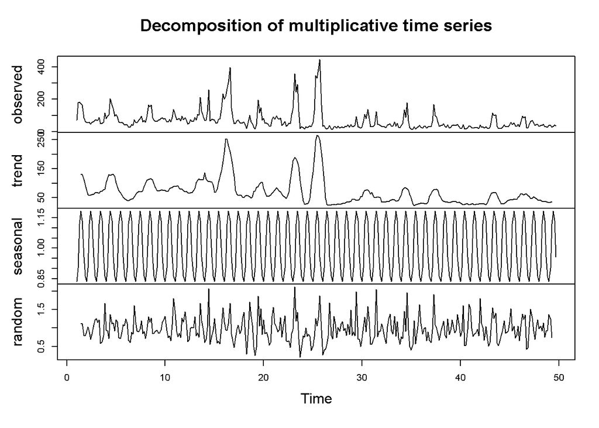

```
##
## #######################
## # KPSS Unit Root Test #
## #######################
##
## Test is of type: mu with 5 lags.
##
## Value of test-statistic is: 0.079
##
## Critical value for a significance level of:
##                 10pct  5pct 2.5pct  1pct
## critical values 0.347 0.463  0.574 0.739
```

The random component is following the zero mean and constant variance assumption. The stationarity achieved as well as we can observe from the KPSS test. The seasonal component shows us that the sales tend to increase towards the middle of the week. We can’t say that there is a particular trend in the sales. But we can say that the sales increases during fall and winter times due to the special days.

# 7.2.b Decomposition at Frequency= 30

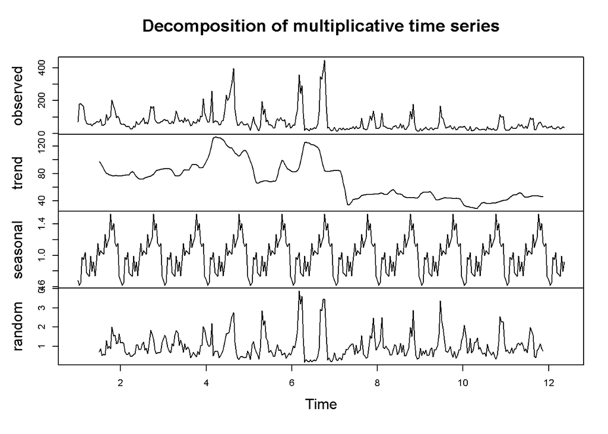

```
##
## #######################
## # KPSS Unit Root Test #
## #######################
##
## Test is of type: mu with 5 lags.
##
## Value of test-statistic is: 0.0136
##
## Critical value for a significance level of:
##                 10pct  5pct 2.5pct  1pct
## critical values 0.347 0.463  0.574 0.739
```

The random component is not following the constant variance and zero mean assumption, however the kpss test shows that stationarity is achieved. The seasonal component shows that there is an increase towards the end of the 30 day period. Finally the trend component shows that the sales are decreasing towards the summer and high in fall.

We will continue with daily decomposition since the random component is poviding a better result.

# 7.3 ARIMA Model

The sinusoidal pattern in the acf plot shows that we can add a AR parameter and p=1 and p=3 are possible options depending on the PACF plot.

PACF plot doesn’t have any sinusoidal or decreasing pattern so there is no need to add a MA parameter.

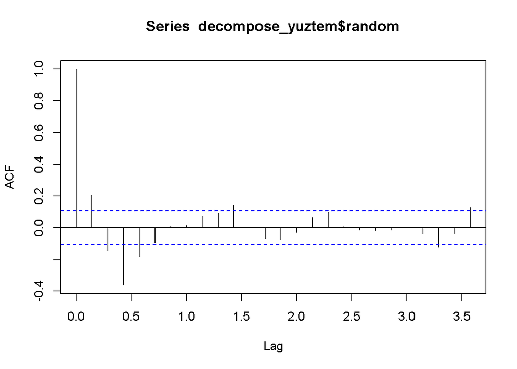

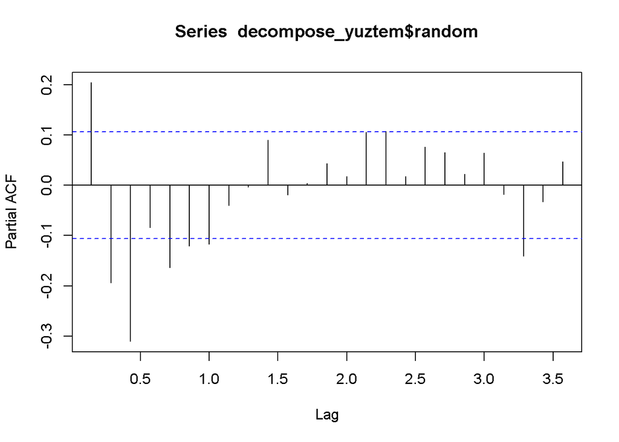

```
##      [,1]               [,2]
## [1,] "model 1"          "model 2"
## [2,] "206.169276636796" "163.09203819223"
```

Since model 2 is providing a lower AIC value it seems to be better than model 1.

# 7.4 Regressor Analysis

```
##
## Call:
## lm(formula = sold_count ~ ., data = data_yuztem)
##
## Residuals:
##     Min      1Q  Median      3Q     Max
## -45.637  -6.698   0.268   7.586  56.707
##
## Coefficients:
##                       Estimate Std. Error t value Pr(>|t|)
## (Intercept)         -1.083e+03  9.387e+02  -1.154 0.249384
## price               -1.719e+00  2.883e-01  -5.965 6.62e-09 ***
## event_date           6.587e-02  5.071e-02   1.299 0.194937
## visit_count         -1.569e-02  2.956e-03  -5.309 2.10e-07 ***
## favored_count       -9.469e-04  4.234e-03  -0.224 0.823175
## basket_count         2.806e-01  1.176e-02  23.854  < 2e-16 ***
## category_sold       -3.012e-02  7.331e-03  -4.108 5.10e-05 ***
## category_brand_sold  3.027e-05  2.185e-04   0.139 0.889915
## category_visits      2.200e-02  1.225e-03  17.955  < 2e-16 ***
## ty_visits           -2.645e-07  1.189e-07  -2.225 0.026774 *
## category_basket      3.556e-04  7.009e-05   5.073 6.71e-07 ***
## category_favored    -4.481e-03  2.590e-04 -17.302  < 2e-16 ***
## w_dayCum            -1.573e+00  2.877e+00  -0.547 0.584868
## w_dayÇar             1.253e+00  2.956e+00   0.424 0.672020
## w_dayPaz            -4.049e-01  2.893e+00  -0.140 0.888811
## w_dayPer            -1.758e+00  2.934e+00  -0.599 0.549530
## w_dayPzt            -6.671e-01  2.910e+00  -0.229 0.818786
## w_daySal             1.969e+00  2.929e+00   0.672 0.501960
## monthAra            -1.711e+01  8.293e+00  -2.063 0.039981 *
## monthEki            -8.003e+00  4.846e+00  -1.651 0.099650 .
## monthEyl            -5.097e+00  3.956e+00  -1.289 0.198490
## monthHaz            -1.022e+01  4.859e+00  -2.103 0.036300 *
## monthKas            -5.545e+00  6.173e+00  -0.898 0.369775
## monthMar            -1.455e+01  9.803e+00  -1.484 0.138840
## monthMay            -2.224e+01  6.612e+00  -3.363 0.000866 ***
## monthNis            -4.299e+00  1.121e+01  -0.384 0.701608
## monthOca            -7.954e+00  9.591e+00  -0.829 0.407563
## monthŞub            -2.064e+01  9.224e+00  -2.238 0.025940 *
## monthTem             7.630e-01  3.901e+00   0.196 0.845065
## ---
## Signif. codes:  0 '***' 0.001 '**' 0.01 '*' 0.05 '.' 0.1 ' ' 1
##
## Residual standard error: 13.91 on 313 degrees of freedom
## Multiple R-squared:  0.9554, Adjusted R-squared:  0.9514
## F-statistic: 239.2 on 28 and 313 DF,  p-value: < 2.2e-16
```

The most significant input attributes can be seen as price, visit_count,basket_count,category_sold,category_visits and category_favored. Since visit_count and category_visits are correlated using only one of them would be a better option and since price has many missing values, we want to avoid using it.

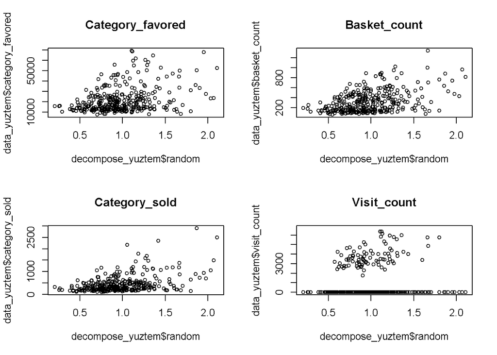

After the visual inspection we decided to continue with basket_count and category_favored as regressors.

# 7.5 ARIMAX Model

Now, we are going to add the regression matrix to the ARIMA models that we found before, and see if there is any improvement.

```
##      [,1]               [,2]               [,3]
## [1,] "model 1"          "model 2"          "auto.arima"
## [2,] "116.927378478595" "121.304823402657" "117.433436230078"
```

```
## Series: decompose_yuztem$random
## Regression with ARIMA(0,1,1)(0,0,1)[7] errors
##
## Coefficients:
##           ma1    sma1   drift   xreg1  xreg2
##       -0.6245  0.0306  0.0025  0.0019      0
## s.e.   0.1035  0.0587  0.0005  0.0002      0
##
## sigma^2 estimated as 0.0813:  log likelihood=-52.72
## AIC=117.43   AICc=117.69   BIC=140.32
##
## Training set error measures:
##                        ME      RMSE       MAE      MPE     MAPE      MASE
## Training set 0.0007446603 0.2825754 0.2235876 5.020472 27.56164 0.6136401
##                   ACF1
## Training set 0.1362777
```

# 7.6 Performance of the Models

```
##    n mean       sd        CV      FBias      MAPE     RMSE      MAD      MADP
## 1: 7   35 7.118052 0.2033729 0.07557723 0.2415933 9.202593 8.383429 0.2395265
##        WMAPE
## 1: 0.2395265
```

```
##    n mean       sd        CV      FBias     MAPE     RMSE      MAD      MADP
## 1: 7   35 7.118052 0.2033729 0.08777577 0.198224 7.901115 7.121234 0.2034638
##        WMAPE
## 1: 0.2034638
```

```
##    n     mean       sd        CV       FBias      MAPE     RMSE      MAD
## 1: 7 35.71429 6.651172 0.1862328 0.009344812 0.2512836 11.65777 8.975412
##         MADP     WMAPE
## 1: 0.2513115 0.2513115
```

The model 2 ,which have parameters (3,0,0), seems to be a better model due to its lower RMSE and MAPE value.

## 8. Model of Bluetooth Headphone Sales

# 8.1 Visualisation of the Data

There is a frequent demand for the headphones. There is no decreasing or increasing trend, but some peaks are observed probably due to some promotions. Highest peak is observed during July 2020.

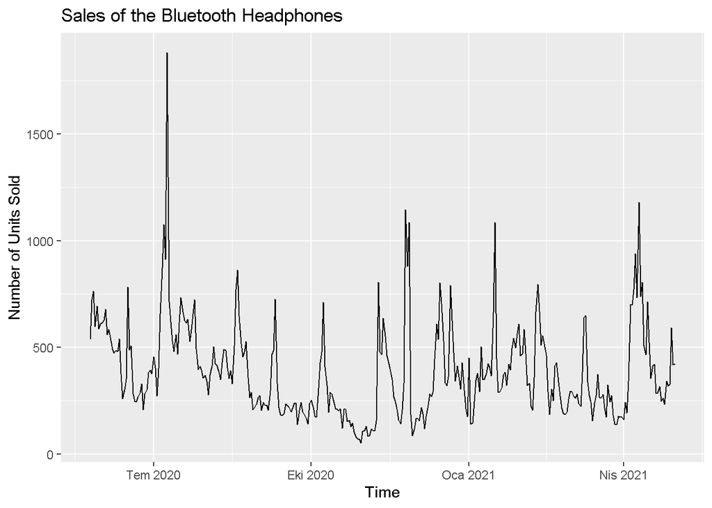

```
##
## #######################
## # KPSS Unit Root Test #
## #######################
##
## Test is of type: mu with 5 lags.
##
## Value of test-statistic is: 0.4509
##
## Critical value for a significance level of:
##                 10pct  5pct 2.5pct  1pct
## critical values 0.347 0.463  0.574 0.739
```

The KPSS test shows that the series is not stationary.

# 8.2 Decomposition

# 8.2.a Daily Decompostion

Since there is no decreasing or increasing variance, additive decomposition is a better option.

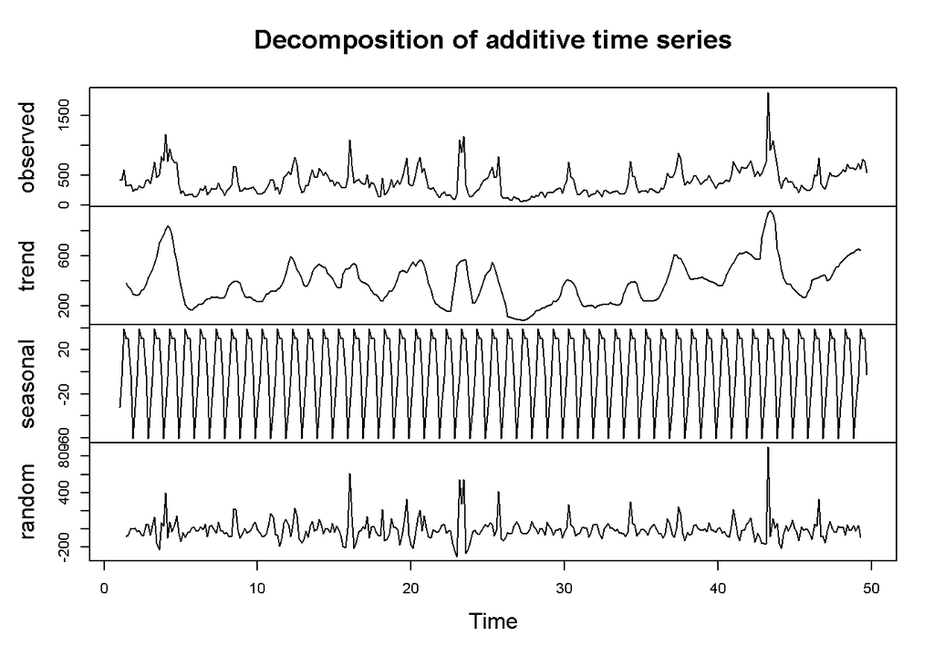

```
##
## #######################
## # KPSS Unit Root Test #
## #######################
##
## Test is of type: mu with 5 lags.
##
## Value of test-statistic is: 0.0101
##
## Critical value for a significance level of:
##                 10pct  5pct 2.5pct  1pct
## critical values 0.347 0.463  0.574 0.739
```

The random component is satisfing the assumptions and kpss test shows that we achieved stationartiy. We can observe the outlier points from the random component. The seasonal component shows that the sales tend to increase towards the middle of the week. There is no particular pattern in the trend component.

# 8.2.b Decompostion at Frequency=30

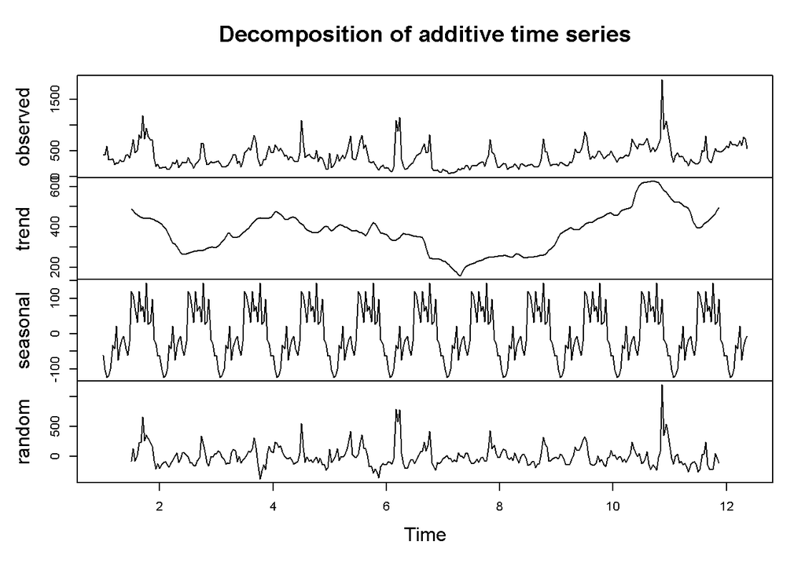

```
##
## #######################
## # KPSS Unit Root Test #
## #######################
##
## Test is of type: mu with 5 lags.
##
## Value of test-statistic is: 0.0489
##
## Critical value for a significance level of:
##                 10pct  5pct 2.5pct  1pct
## critical values 0.347 0.463  0.574 0.739
```

The random component is satisfying the assumptions and the kpss test shows that we achieved stationarity. The seasonal component shows that sales are increasing towards the end of the 30-day period and the trend component doesn’t show any particular pattern.

We will continue with daily decomposition due to the better distribution of the random component.

# 8.3 ARIMA Model

P=1 and p=3 can be used as an AR parameter depending on the sinusoidal pattern in the ACF plot and the decreasing significance in PACF after lag3. There is no need for MA parameter.

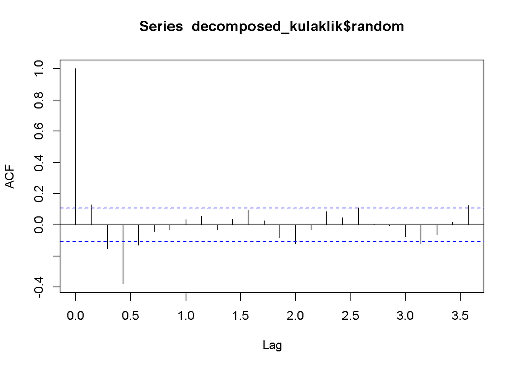

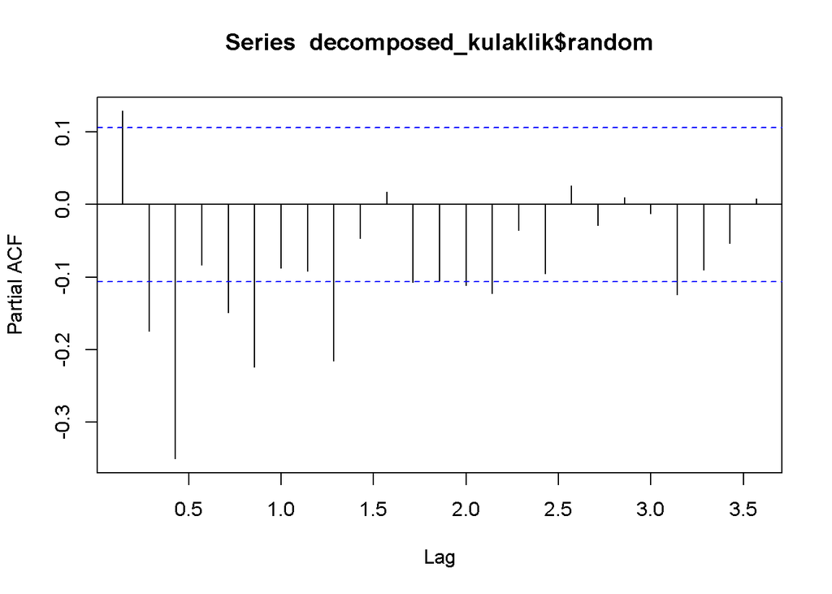

```
##      [,1]               [,2]
## [1,] "model 1"          "model 2"
## [2,] "4176.01276366135" "4125.77861819121"
```

Model 2, which has parameters (3,0,0) is better due to its lower AIC.

# 8.4 Regressor Analysis

```
##
## Call:
## lm(formula = sold_count ~ ., data = data_kulaklik)
##
## Residuals:
##      Min       1Q   Median       3Q      Max
## -314.112  -25.246   -0.592   25.567  190.031
##
## Coefficients:
##                       Estimate Std. Error t value Pr(>|t|)
## (Intercept)          4.904e+03  3.468e+03   1.414  0.15838
## price               -1.923e+00  4.350e-01  -4.420 1.36e-05 ***
## event_date          -2.492e-01  1.872e-01  -1.331  0.18417
## visit_count         -4.122e-03  1.274e-03  -3.235  0.00135 **
## favored_count       -1.511e-02  1.044e-02  -1.446  0.14909
## basket_count         1.957e-01  9.905e-03  19.754  < 2e-16 ***
## category_sold        2.319e-01  2.413e-02   9.611  < 2e-16 ***
## category_brand_sold  1.025e-03  9.173e-04   1.117  0.26478
## category_visits      2.931e-02  4.051e-03   7.236 3.59e-12 ***
## ty_visits            6.495e-07  5.552e-07   1.170  0.24299
## category_basket     -6.857e-06  2.208e-04  -0.031  0.97524
## category_favored    -1.235e-02  1.065e-03 -11.589  < 2e-16 ***
## w_dayCum             2.174e+00  1.031e+01   0.211  0.83315
## w_dayÇar             1.857e+01  1.048e+01   1.772  0.07735 .
## w_dayPaz             4.038e+00  1.019e+01   0.396  0.69222
## w_dayPer             9.122e+00  1.059e+01   0.861  0.38982
## w_dayPzt             4.879e+00  1.047e+01   0.466  0.64163
## w_daySal             1.561e+01  1.039e+01   1.502  0.13398
## monthAra             3.907e+01  3.001e+01   1.302  0.19386
## monthEki             1.284e+01  1.877e+01   0.684  0.49451
## monthEyl            -4.371e+01  1.469e+01  -2.976  0.00315 **
## monthHaz             3.475e+01  1.725e+01   2.015  0.04474 *
## monthKas             7.138e+00  2.389e+01   0.299  0.76530
## monthMar            -4.101e+01  4.171e+01  -0.983  0.32634
## monthMay             6.361e+01  2.271e+01   2.801  0.00540 **
## monthNis             3.864e+01  3.919e+01   0.986  0.32491
## monthOca             1.784e+01  3.445e+01   0.518  0.60483
## monthŞub             1.817e+01  3.977e+01   0.457  0.64816
## monthTem             4.898e+00  1.471e+01   0.333  0.73941
## ---
## Signif. codes:  0 '***' 0.001 '**' 0.01 '*' 0.05 '.' 0.1 ' ' 1
##
## Residual standard error: 49.66 on 313 degrees of freedom
## Multiple R-squared:  0.9539, Adjusted R-squared:  0.9497
## F-statistic: 231.1 on 28 and 313 DF,  p-value: < 2.2e-16
```

The most significant input attributes are price, basket_count, category_sold, category_visits and category_favored. Due to the dirty nature of price we decided not to use it as a regressor.

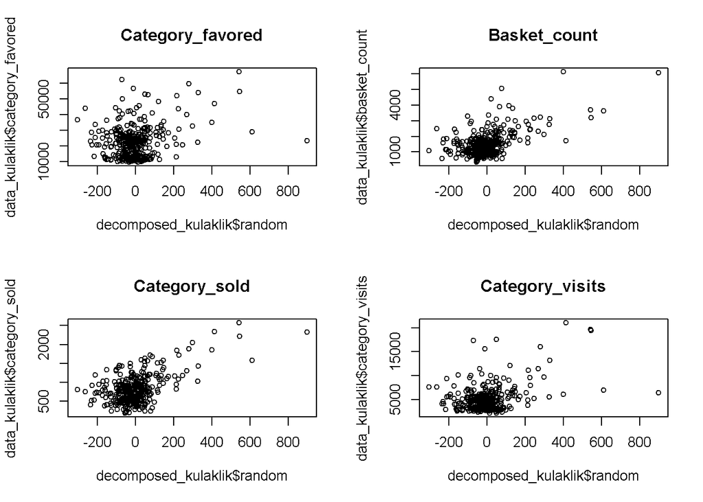

After the visual inspection we decided that all of the attributes can be used as regressors.

# 8.5 ARIMAX Model

```
##      [,1]               [,2]               [,3]
## [1,] "model 1"          "model 2"          "auto.arima"
## [2,] "3857.25654138185" "3859.14725627509" "3853.86920356594"
```

The AIC values decreased significantly and model 1 is providing a better result. The SARIMAX model, which is found by using the Auto.arima function provided a slightly better result with parameters (1,0,0)(0,0,1)[7].

# 8.6 Performance of the Models

```
##    n     mean       sd         CV    FBias     MAPE     RMSE    MAD     MADP
## 1: 7 629.8571 41.50273 0.06589228 99.72301 514.0904 458247.6 323151 513.0545
##       WMAPE
## 1: 513.0545
```

```
##    n     mean       sd         CV    FBias     MAPE     RMSE      MAD     MADP
## 1: 7 629.8571 41.50273 0.06589228 109.0482 512.4252 451864.4 321789.3 510.8925
##       WMAPE
## 1: 510.8925
```

```
##    n mean       sd         CV    FBias    MAPE     RMSE      MAD     MADP
## 1: 7  601 48.07286 0.07998812 283.5352 632.848 615842.3 399456.7 664.6535
##       WMAPE
## 1: 664.6535
```

## 9. Model of Coat Sales

# 9.1 Visualisation of the Data

The sales of the coat is following a pattern, where the sales are increasing during fall and approach to zero during summer and spring time. Due to the lack of data it’s hard to comment on whether there is an increasing or decreasing trend.

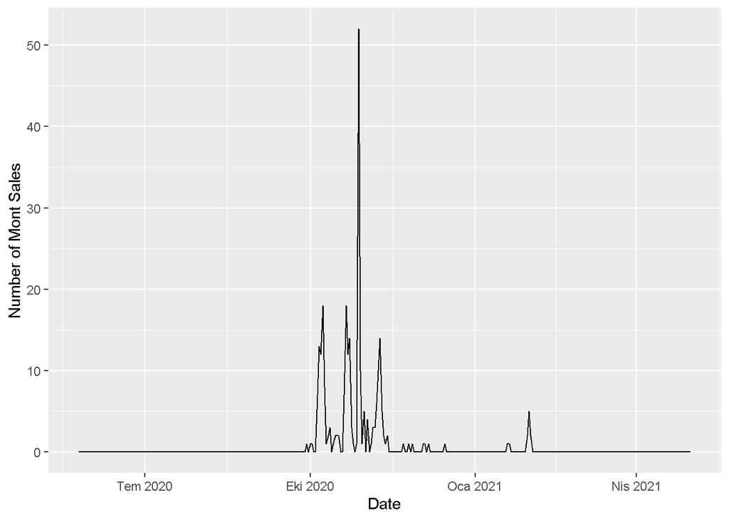

```r
ggplot(data_mont,aes(event_date,sold_count)) + geom_line() + xlab("Date") + ylab("Number of Mont Sales")
```

The result of the KPSS test shows that the data is not stationary, which means that the data have seasonal and trend components which must me removed to achieve stationarity.

```r
summary(ur.kpss(data_mont$sold_count))
```

```
##
## #######################
## # KPSS Unit Root Test #
## #######################
##
## Test is of type: mu with 5 lags.
##
## Value of test-statistic is: 0.4021
##
## Critical value for a significance level of:
##                 10pct  5pct 2.5pct  1pct
## critical values 0.347 0.463  0.574 0.739
```

# 9.2 Decomposition

# 9.2.a Daily Decompostion

In order to remove the effect of increasing variance during the fall, multiplicative decomposition can be applied.

Below you can find the plot of the multiplicative decomposition and the result of the KPSS test. KPSS test shows that the stationarity is achieved, however the random component doesn’t really satisfy the mean zero assumption. So, we can check the additive decomposition as well.

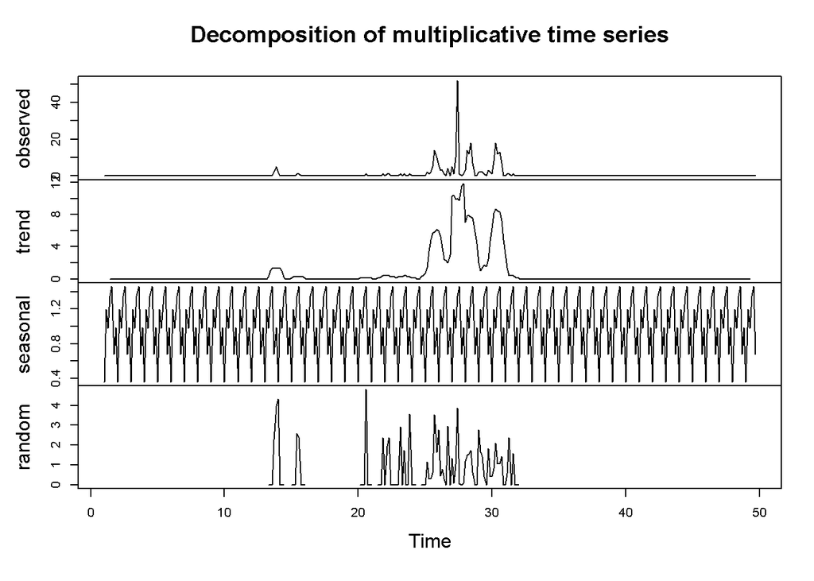

```
##
## #######################
## # KPSS Unit Root Test #
## #######################
##
## Test is of type: mu with 3 lags.
##
## Value of test-statistic is: 0.0518
##
## Critical value for a significance level of:
##                 10pct  5pct 2.5pct  1pct
## critical values 0.347 0.463  0.574 0.739
```

In the additive decomposition we achieved a better distribution in the random component since the zero mean assumption is achieved. Also the KPSS test shows that the random component is stationary.However, some unusual peaks are observed in the random component due to the outliers. The trend component shows an increase during the fall and the beginning of winter. Since there is no sales during summer and spring, the trend is zero during these times. The daily seasonality shows that the sales are increasing in the beginning of the week and decreasing towards the end of the week.

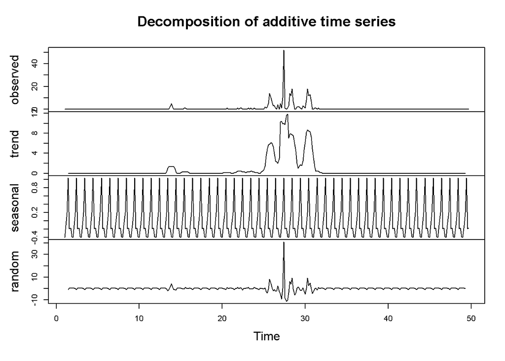

```
##
## #######################
## # KPSS Unit Root Test #
## #######################
##
## Test is of type: mu with 5 lags.
##
## Value of test-statistic is: 0.01
##
## Critical value for a significance level of:
##                 10pct  5pct 2.5pct  1pct
## critical values 0.347 0.463  0.574 0.739
```

# 9.2.b Addition of lagged variables

In order to decide on which lagged variables to use, we should check the ACF and PACF plots. We can’t observe any seasonality in the ACF plot since the peaks are not following a periodical pattern. However, there is a high autocorrelation in lag 1, which suggests that today’s sales are affecting tomorrow’s sales, so we decided to add lag 1. We decided to add lag 7 as well to check for the weekly seasonality.

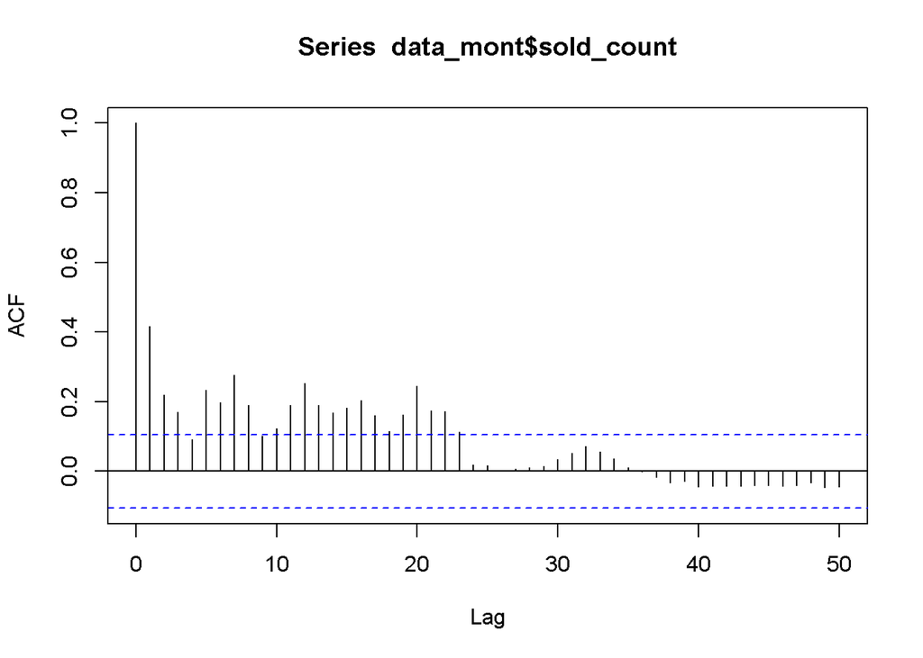

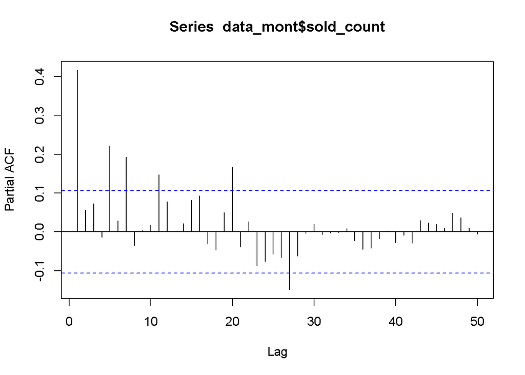

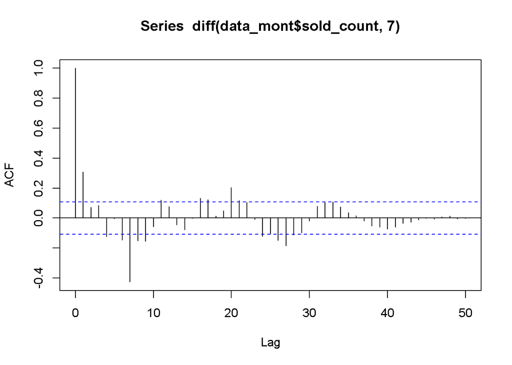

```
##
## #######################
## # KPSS Unit Root Test #
## #######################
##
## Test is of type: mu with 5 lags.
##
## Value of test-statistic is: 0.0253
##
## Critical value for a significance level of:
##                 10pct  5pct 2.5pct  1pct
## critical values 0.347 0.463  0.574 0.739
```

Lag 7 differencing improved the ACF plot, but still there is high autocorrelation in lag 1. Also, according to the KPSS test we achieved stationarity.

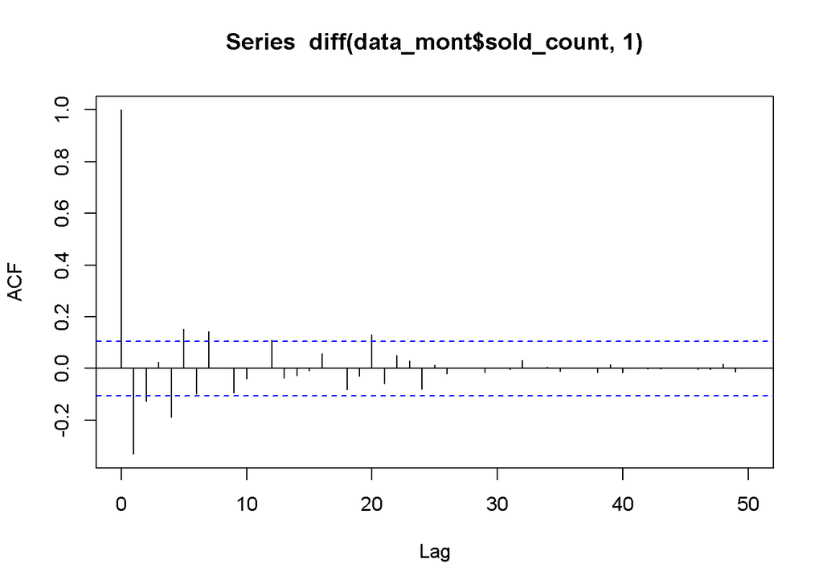

```
##
## #######################
## # KPSS Unit Root Test #
## #######################
##
## Test is of type: mu with 5 lags.
##
## Value of test-statistic is: 0.0115
##
## Critical value for a significance level of:
##                 10pct  5pct 2.5pct  1pct
## critical values 0.347 0.463  0.574 0.739
```

Lag 1 differencing provided a great result on KPSS test and the ACF plot improved as well. So, the next step is to add lag 1 and lag 7 to the data set and we will continue with that data set.

# 9.3 ARIMA Models

ACF and PACF plots are helpful visualization tools for finding the appropriate parameters to use in the ARIMA model.

There is a sinusoidal pattern in the ACF plot, so AR parameter can be added. In order to find the value of the AR parameter PACF plot has to be checked.The significance of partial autocorrelation is decreasing after lag 1 so p=1 can be used.

PACF plot has a sinusoidal pattern as well. The high autocorrelation at lag 1 in the ACF plot shows that we can use q=1. Also, q=5 can be used.

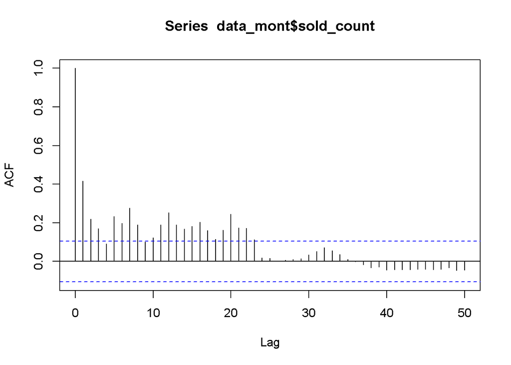

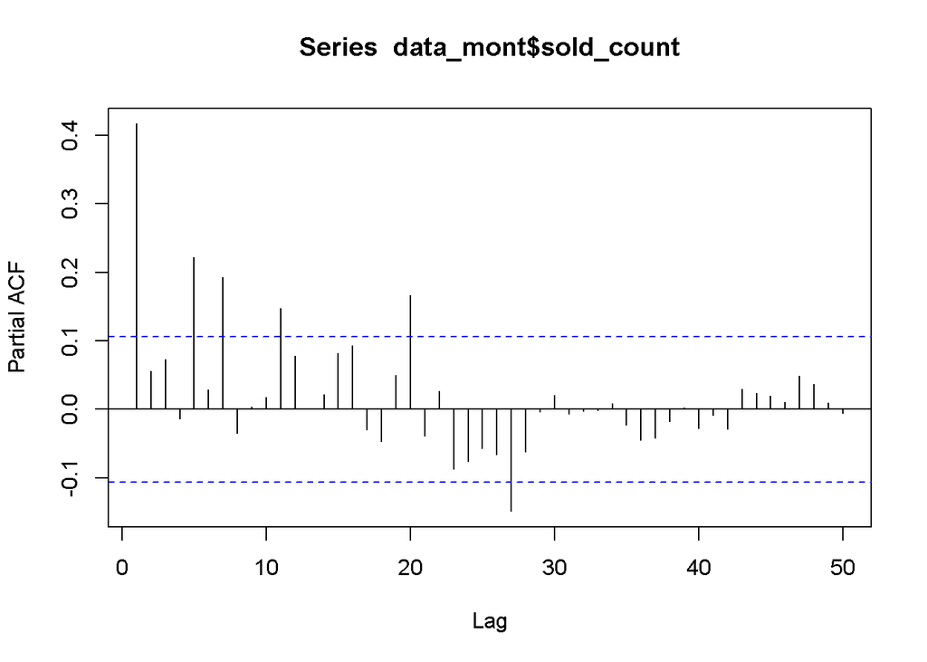

The following ARIMA models with parameters (1,0,5) and (1,0,1) are built depending on our parameter analysis. Model 1 is chosen due to its lower AIC value.

```
##
## Call:
## arima(x = data_mont$sold_count, order = c(1, 0, 5))
##
## Coefficients:
##          ar1      ma1      ma2     ma3      ma4     ma5  intercept
##       0.9624  -0.5916  -0.2873  0.0397  -0.1774  0.1796     0.6974
## s.e.  0.0212   0.0583   0.0618  0.0664   0.0602  0.0483     0.7056
##
## sigma^2 estimated as 10.06:  log likelihood = -880.37,  aic = 1776.73
##
## Training set error measures:
##                     ME     RMSE       MAE  MPE MAPE     MASE         ACF1
## Training set 0.0134782 3.171325 0.8939637 -Inf  Inf 1.154703 -0.003198192
```

```
##
## Call:
## arima(x = data_mont$sold_count, order = c(1, 0, 1))
##
## Coefficients:
##          ar1      ma1  intercept
##       0.5816  -0.2054     0.7748
## s.e.  0.1333   0.1679     0.3393
##
## sigma^2 estimated as 10.99:  log likelihood = -895.23,  aic = 1798.47
##
## Training set error measures:
##                       ME     RMSE       MAE  MPE MAPE     MASE       ACF1
## Training set 0.002095439 3.314844 0.9878193 -Inf  Inf 1.275933 0.01062846
```

## 9.4 Regressor Analysis

In order to find which regressors to use in the model linear regression model is built. Some additional regressors like weekday and month info are introduced to the data, which may account for the sale patterns of the product.

```
##
## Call:
## lm(formula = sold_count ~ ., data = data_mont)
##
## Residuals:
##    Min     1Q Median     3Q    Max
## -6.275 -1.082  0.000  0.931  5.021
##
## Coefficients: (1 not defined because of singularities)
##                       Estimate Std. Error t value Pr(>|t|)
## (Intercept)         -4.106e+02  1.205e+03  -0.341  0.73621
## price               -1.368e-02  6.347e-03  -2.155  0.04095 *
## event_date           2.182e-02  6.460e-02   0.338  0.73833
## visit_count          1.953e-01  1.163e-01   1.679  0.10571
## favored_count       -2.060e-01  6.252e-01  -0.329  0.74457
## basket_count         1.927e-01  1.352e-02  14.254 1.65e-13 ***
## category_sold       -1.852e-03  2.015e-03  -0.919  0.36700
## category_brand_sold  1.423e-04  1.164e-04   1.222  0.23315
## category_visits      1.556e-04  9.229e-05   1.686  0.10428
## ty_visits           -1.911e-06  1.590e-06  -1.202  0.24056
## category_basket      6.127e-05  5.600e-05   1.094  0.28433
## category_favored    -8.964e-05  2.757e-05  -3.251  0.00328 **
## w_dayCum             2.343e-01  1.754e+00   0.134  0.89477
## w_dayÇar             1.277e+00  2.038e+00   0.627  0.53653
## w_dayPaz            -1.942e+00  2.066e+00  -0.940  0.35635
## w_dayPer             1.326e+00  1.808e+00   0.733  0.47008
## w_dayPzt             3.775e-01  2.320e+00   0.163  0.87203
## w_daySal            -3.780e+00  2.338e+00  -1.617  0.11840
## monthEki             1.910e+01  1.805e+01   1.058  0.30009
## monthEyl             2.324e+01  1.886e+01   1.233  0.22918
## monthKas             1.899e+01  1.753e+01   1.083  0.28924
## monthOca            -1.377e+01  1.390e+01  -0.990  0.33158
## monthŞub                    NA         NA      NA       NA
## lag1                 9.017e-02  6.766e-02   1.333  0.19465
## lag7                -6.299e-02  5.874e-02  -1.072  0.29381
## ---
## Signif. codes:  0 '***' 0.001 '**' 0.01 '*' 0.05 '.' 0.1 ' ' 1
##
## Residual standard error: 2.884 on 25 degrees of freedom
##   (293 observations deleted due to missingness)
## Multiple R-squared:  0.9374, Adjusted R-squared:  0.8798
## F-statistic: 16.28 on 23 and 25 DF,  p-value: 6.135e-10
```

Basket_count and category_favored can be used due to their high significance in the model compared to other attributes.

```
##
## Call:
## lm(formula = sold_count ~ basket_count + category_favored, data = data_mont)
##
## Residuals:
##      Min       1Q   Median       3Q      Max
## -11.3413  -0.4563  -0.1114   0.4560   8.2868
##
## Coefficients:
##                    Estimate Std. Error t value Pr(>|t|)
## (Intercept)       5.423e-01  1.130e-01   4.800 2.39e-06 ***
## basket_count      1.841e-01  4.274e-03  43.082  < 2e-16 ***
## category_favored -1.959e-05  2.370e-06  -8.267 3.15e-15 ***
## ---
## Signif. codes:  0 '***' 0.001 '**' 0.01 '*' 0.05 '.' 0.1 ' ' 1
##
## Residual standard error: 1.423 on 339 degrees of freedom
## Multiple R-squared:  0.8496, Adjusted R-squared:  0.8488
## F-statistic: 957.8 on 2 and 339 DF,  p-value: < 2.2e-16
```

The linear regression model with the basket_count and category_favored attributes seems to be valid depending on the low p-value for the overall model and the high value of adjusted R-squared.

So, we decided to use basket_count and category_favored attributes as regressors.

# 9.5 ARIMAX Model

Basket_count and Category_favored attributes are added to the ARIMA model found in section 9.3. The AIC value decreased significantly, which is a sign for improvement.

```
##
## Call:
## arima(x = data_mont$sold_count, order = c(1, 0, 5), xreg = regressor_mont)
##
## Coefficients:
```

```
##           ar1     ma1     ma2     ma3     ma4     ma5  intercept
##       -0.6450  0.9422  0.5939  0.5647  0.2033  0.1059     0.8106
## s.e.   0.1677  0.1696  0.0746  0.0832  0.0851  0.0513     0.1855
##       regressor_mont1  regressor_mont2
##                0.2011                0
## s.e.           0.0046              NaN
##
## sigma^2 estimated as 1.544:  log likelihood = -559.88,  aic = 1139.75
##
## Training set error measures:
##                        ME     RMSE       MAE MPE MAPE     MASE        ACF1
## Training set 2.518335e-05 1.242576 0.6559494 NaN  Inf 0.847268 0.001492097
```

# 9.6 Performance of the Models

The one week forecast is made with the three different models that are found throughout the analysis process. Each model is evaluated with performance measures.

```
## [1] "2021-04-25" "2021-04-26" "2021-04-27" "2021-04-28" "2021-04-29"
## [6] "2021-04-30" "2021-05-01"
```

```
##    variable n mean sd  CV FBias MAPE RMSE MAD MADP WMAPE
## 1:   model1 7    0  0 NaN   NaN  NaN    0   0  NaN   NaN
## 2:   model2 7    0  0 NaN   NaN  NaN    0   0  NaN   NaN
## 3:   model3 7    0  0 NaN   NaN  NaN    0   0  NaN   NaN
```

```
##    variable n mean sd  CV FBias MAPE RMSE MAD MADP WMAPE
## 1:   model1 7    0  0 NaN   NaN  NaN    0   0  NaN   NaN
## 2:   model2 7    0  0 NaN   NaN  NaN    0   0  NaN   NaN
## 3:   model3 7    0  0 NaN   NaN  NaN    0   0  NaN   NaN
```

Since the forecasts are equal to 0, we get NA’s in some of the performance measured, that’s why we are not able to compare the models.

## 10. Model of Vacuum Cleaner Sales

# 10.1 Visualisation of the Data

Sales of Vacuum Cleaner doesn’t seem to have any seasonal pattern. Probably the small peaks in the sales are during promotion times. Again we are observing a very high peak during the Black Friday, which can be categorized as an outlier point.

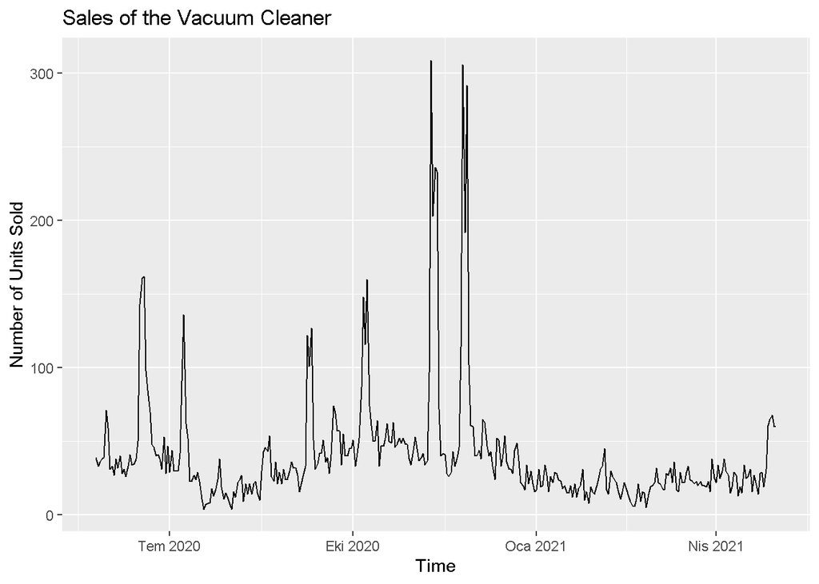

The KPSS test shows that the series is not stationary

```
##
## #######################
## # KPSS Unit Root Test #
## #######################
##
## Test is of type: mu with 5 lags.
##
## Value of test-statistic is: 0.5403
##
## Critical value for a significance level of:
##                 10pct  5pct 2.5pct  1pct
## critical values 0.347 0.463  0.574 0.739
```

# 10.2 Decomposition

# 10.2.a Daily Decompostion (Frequency=7)

Multiplicative decomposition is a better option due to the increasing variance, especially during the November and December.

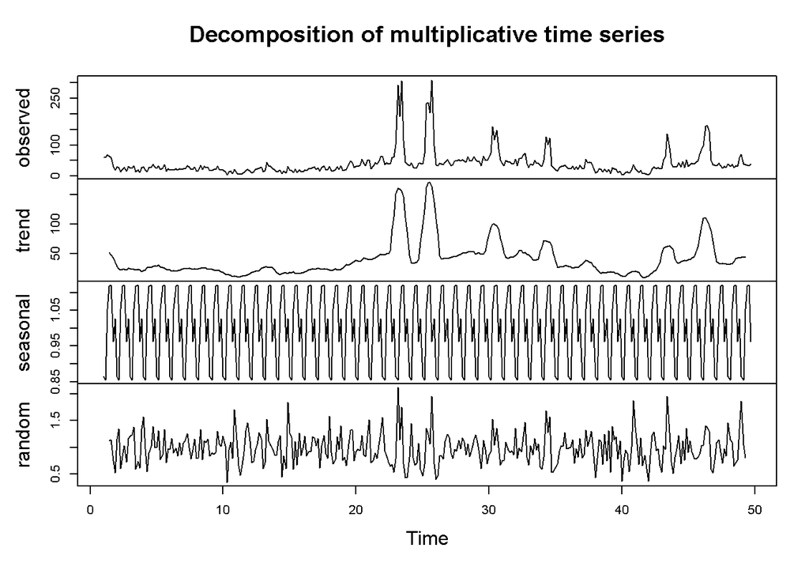

```
##
## #######################
## # KPSS Unit Root Test #
## #######################
##
## Test is of type: mu with 5 lags.
##
## Value of test-statistic is: 0.0804
##
## Critical value for a significance level of:
##                 10pct  5pct 2.5pct  1pct
## critical values 0.347 0.463  0.574 0.739
```

We can see that we achieved stationarity depending on the KPSS test. Also the random component is following the mean zero and constant variance assumptions. The seasonal component shows that the sales tend to increase towards the middle of the weak, and decrease towards the end of the week. There is no specific trend, but we can observe the effect of Black Friday on the trend component.

We can continue with daily decomposition since random component satisfies the assumptions and stationarity is achieved.

# 10.2.b Decompostion at Frequency=30

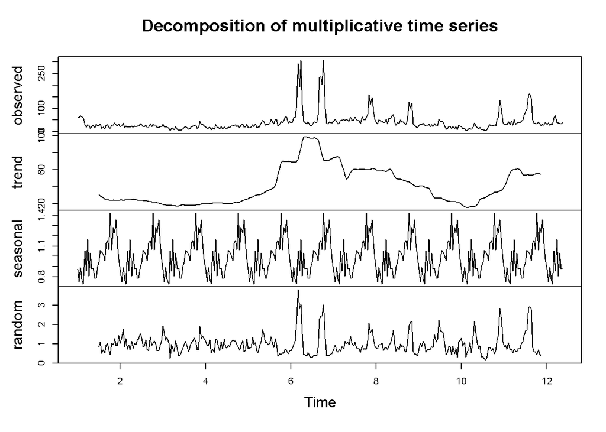

```
##
## #######################
## # KPSS Unit Root Test #
## #######################
##
## Test is of type: mu with 5 lags.
##
## Value of test-statistic is: 0.0162
##
## Critical value for a significance level of:
##                 10pct  5pct 2.5pct  1pct
## critical values 0.347 0.463  0.574 0.739
```

The KPSS test shows that we achieved stationarity, and the random component is following the constant variance assumption, however the it is not following the zero mean assumption. The trend component shows the increase in sales during the fall.The seasonality component shows that in every 30-day period the sales tend to increase towards the end of that period.

Since the daily decomposition is providing a better random component we will continue with it.

# 10.3 ARIMA Model

First we need to check ACF and PACF to decide on which parameter to use.

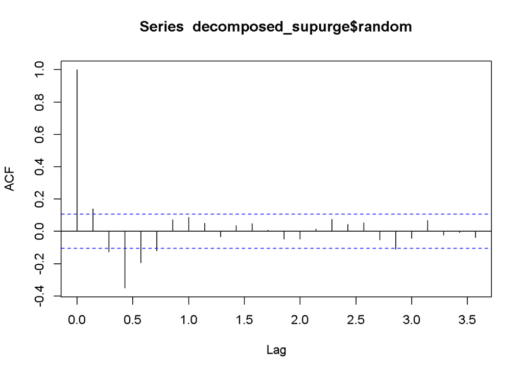

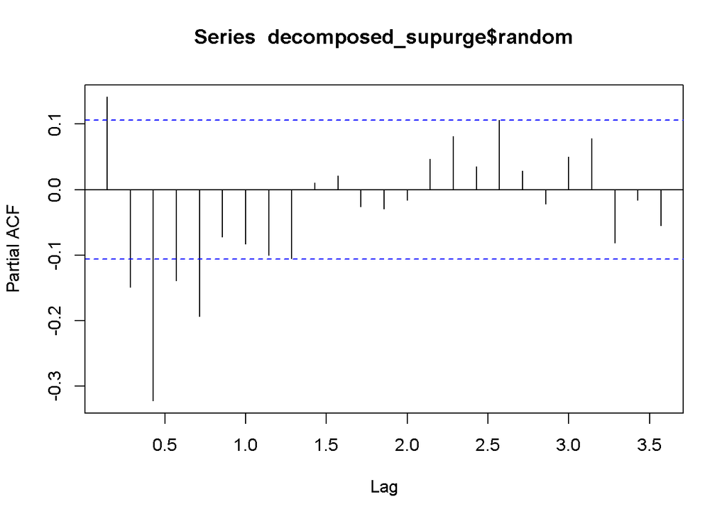

We can add MA parameter as well, since PACF plot is following a sinusoidal pattern. Depending on the ACF plot, we can try several values as MA parameter such as q=1 and q=2.

```
##      [,1]               [,2]
## [1,] "model 1"          "model 2"
## [2,] "79.9204679653259" "71.3240822492"
```

The model 2 ,which have parameters (2,0,2), seems to be a better model due to its lower AIC value.

# 10.4 Regressor Analysis

In order to find the significance of the input attributes on explaining the sold_count, we built a linear regression model.Then we plotted the ones with high significance values with the random component. We chose the ones that would work well on explaining the behavior of the random component. Note that this method is going to be used for every product.

```
##
## Call:
## lm(formula = sold_count ~ ., data = data_supurge)
##
## Residuals:
##     Min      1Q  Median      3Q     Max
## -37.671  -3.887  -0.282   3.839  32.833
##
## Coefficients:
##                       Estimate Std. Error t value Pr(>|t|)
## (Intercept)         -1.041e+03  4.975e+02  -2.093 0.037150 *
## price               -3.195e-01  7.769e-02  -4.113 5.00e-05 ***
## event_date           6.002e-02  2.727e-02   2.201 0.028486 *
## visit_count         -1.638e-03  2.923e-03  -0.560 0.575641
## favored_count        3.384e-03  9.372e-03   0.361 0.718273
## basket_count         1.976e-01  9.599e-03  20.585  < 2e-16 ***
## category_sold        1.414e-01  1.391e-02  10.166  < 2e-16 ***
## category_brand_sold -9.965e-05  3.795e-04  -0.263 0.793054
## category_visits      3.601e-02  3.726e-03   9.664  < 2e-16 ***
## ty_visits           -1.883e-07  6.117e-08  -3.078 0.002270 **
## category_basket      2.592e-04  8.457e-05   3.065 0.002366 **
## category_favored    -1.214e-02  8.033e-04 -15.119  < 2e-16 ***
## w_dayCum             1.062e+00  1.542e+00   0.689 0.491550
## w_dayÇar            -3.493e-01  1.557e+00  -0.224 0.822645
## w_dayPaz             1.914e+00  1.536e+00   1.246 0.213658
## w_dayPer             6.397e-01  1.558e+00   0.410 0.681749
## w_dayPzt             3.555e-01  1.543e+00   0.230 0.817991
## w_daySal            -7.812e-01  1.551e+00  -0.504 0.614911
## monthAra             1.006e+01  5.204e+00   1.934 0.054011 .
## monthEki             1.475e+01  2.616e+00   5.639 3.82e-08 ***
## monthEyl             8.369e+00  2.139e+00   3.912 0.000112 ***
## monthHaz             1.333e+01  2.548e+00   5.232 3.08e-07 ***
## monthKas             1.895e+01  3.542e+00   5.351 1.69e-07 ***
## monthMar             1.497e+01  5.673e+00   2.638 0.008755 **
## monthMay             1.327e+01  3.426e+00   3.873 0.000131 ***
## monthNis             1.097e+01  6.070e+00   1.807 0.071704 .
## monthOca             1.329e+01  5.294e+00   2.510 0.012588 *
## monthŞub             1.234e+01  5.453e+00   2.264 0.024280 *
## monthTem             5.353e+00  2.098e+00   2.552 0.011201 *
## ---
## Signif. codes:  0 '***' 0.001 '**' 0.01 '*' 0.05 '.' 0.1 ' ' 1
##
## Residual standard error: 7.454 on 313 degrees of freedom
## Multiple R-squared:  0.9682, Adjusted R-squared:  0.9654
## F-statistic: 340.8 on 28 and 313 DF,  p-value: < 2.2e-16
```

The most significant input attributes can be seen as basket_count,category_sold,category_visits and category_favored.

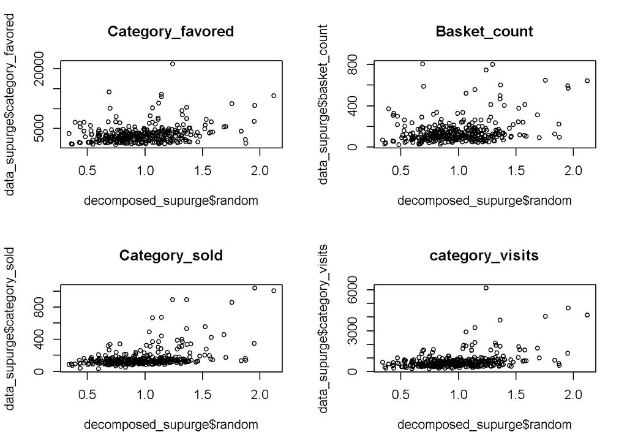

We chose to use category_favored and basket_count as regressors since they have provide a better distribution with the random component.

# 10.5 ARIMAX Model

Now, we are going to add the regression matrix to the ARIMA models that we found before, and see if there is any improvement.

```
##      [,1]               [,2]               [,3]
## [1,] "model 1"          "model 2"          "auto.arima"
## [2,] "81.1908278887521" "100.819757387839" "104.035129405235"
```

# 10.6 Performance of the Models

Now we will evaluate the models over a one week test period.

```
##    n     mean       sd        CV      FBias      MAPE     RMSE      MAD
## 1: 7 42.57143 16.22608 0.3811496 0.09655078 0.2260242 13.22904 10.33344
##         MADP     WMAPE
## 1: 0.2427318 0.2427318
```

```
##    n     mean       sd        CV     FBias      MAPE    RMSE      MAD      MADP
## 1: 7 42.57143 16.22608 0.3811496 0.1008832 0.1903115 12.9939 9.209244 0.2163245
##        WMAPE
## 1: 0.2163245
```

```
##    n     mean     sd        CV       FBias     MAPE     RMSE      MAD      MADP
## 1: 7 37.14286 10.574 0.2846847 -0.09839679 0.227109 9.364637 7.783161 0.2095466
##        WMAPE
## 1: 0.2095466
```

The model 3 ,which have parameters (0,0,1), seems to be a better model due to its lower RMSE value.

# 11. Conclusion